# Supplementary Materials

Peter J. Kohler and Alasdair D. F. Clarke

This will be merged into the main file later

# 1 Loading packages and importing data

## 1.1 Packages

Details of packages, etc, are given below.

## 1.2 Import Data

Here we import our data and make some summary plots.

### 1.2.1 EEG Data

Importing the primary EEG data set. This is odd-harmonic filtered data from region-of-interest consisting of six electrodes over occipital cortex.

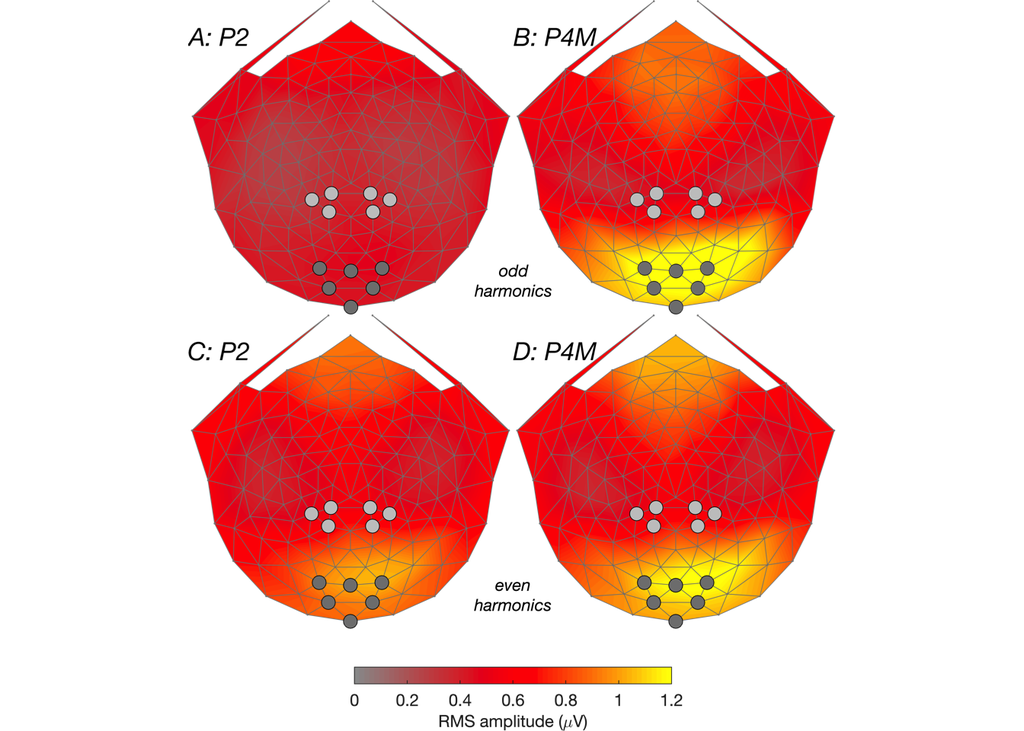

Figure 1.1: RMS data from two of the wallpaper groups, P2 and P4M. Odd harmonics are shown in A and B, while even harmonic data are shown in C and D, and occipital and parietal regions of interest are shown in dark nad light gray, respectively. The two groups elicit very different response amplitudes for odd harmonics over occipital cortex, but for even harmonics those differences are much less pronounced.

```
## Observations: 400
## Variables: 3
## $ wg      <chr> "P2", "PM", "PG", "CM", "PMM", "PMG", "PGG", "CMM", "P4"…
## $ subject <chr> "s01", "s01", "s01", "s01", "s01", "s01", "s01", "s01", …
## $ rms     <dbl> 0.4013, 0.6555, 0.5547, 0.7635, 0.9185, 0.7285, 0.4320, …
```

It’s clearly skewed, and negative display duration are impossible, so will fit a `glm` with `family = 'lognormal'`.

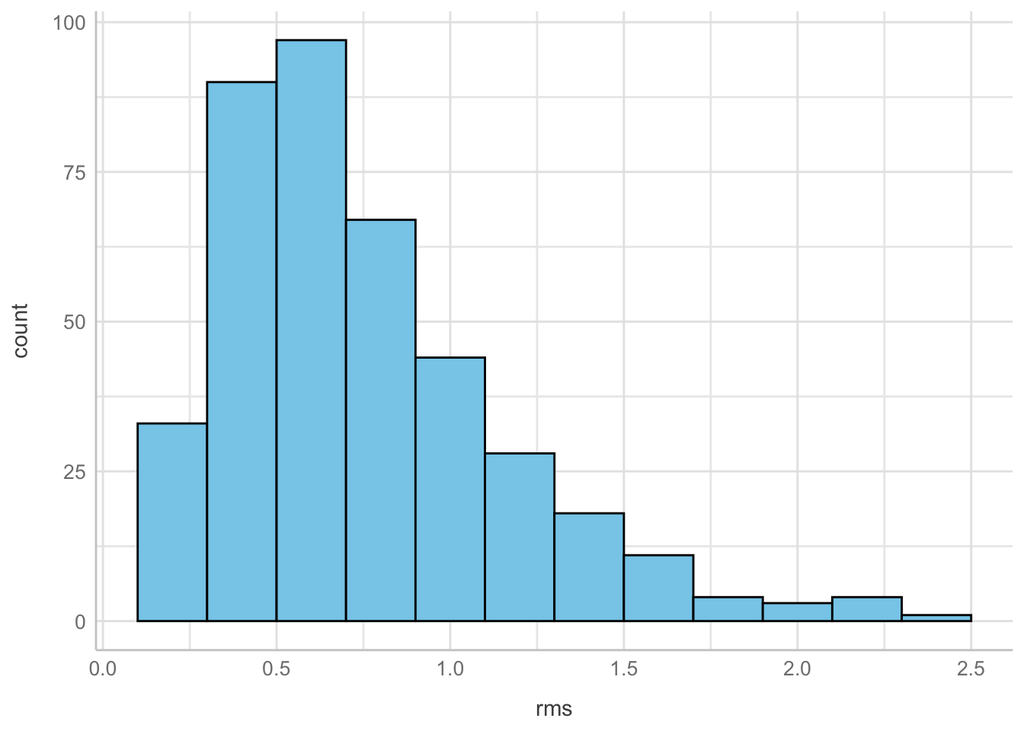

Figure 1.2: Data are the root-mean-squaured (rms) over the odd-harmonic filtered waveforms.

### 1.2.2 Threshold Data

Here we import that data and select the columns that we’re interested in. Threshold gives the required display duration (in seconds) for the two stimuli to allow for accurate discrimination.

```
## Observations: 186
## Variables: 3
## $ subject   <chr> "person10", "person10", "person10", "person10", "perso…
## $ wg        <chr> "CM", "CMM", "P2", "P3", "P31M", "P3M1", "P4", "P4G", …
## $ threshold <dbl> 0.74125, 0.20216, 0.47697, 0.35012, 0.24529, 0.19022, …
```

As above, a summary of the data.

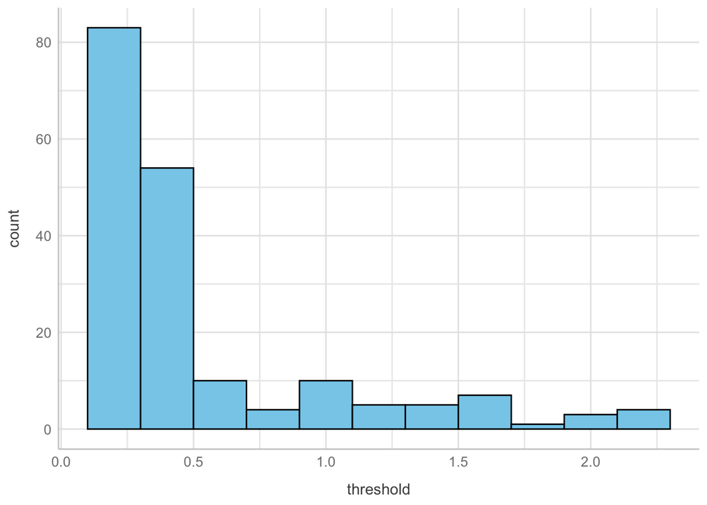

Figure 1.3: Histogram of the display duration thresholds.

Again, we have a skewed distribution, so will fit with `family = 'lognormal'`.

### 1.2.3 Control Data

In addition to the primary EEG data set, we are also importing two control data sets which are (a) even harmonic data from the same occipital electrodes, and (b) odd harmonic data from six parietal electrodes (see Figure 1.1 and the main paper).

## 1.3 Symmetry Information

### 1.3.1 Subgroup Relationships

Import subgroup information and display a table of the relationships that we will be investigating.

```
## Observations: 63
## Variables: 5
## $ group    <chr> "PG", "PG", "P2", "PG", "P2", "PG", "PM", "CM", "PGG", …
## $ subgroup <chr> "PM", "CM", "PGG", "PGG", "PMG", "PMG", "PMG", "PMG", "…
## $ index    <dbl> 2, 2, 2, 2, 2, 2, 2, 4, 2, 2, 4, 2, 4, 4, 2, 2, 4, 4, 2…
## $ normal   <lgl> TRUE, TRUE, TRUE, TRUE, TRUE, TRUE, TRUE, FALSE, TRUE, …
## $ label    <chr> "PG $\\rightarrow$ PM", "PG $\\rightarrow$ CM", "P2 $\\…
```

Table 1.1: subgroup index

| subgroup | P2 | PG | PM | CM | PGG | PMG | PMM | CMM | P4 | P4G | P4M | P3 | P3M1 | P31M | P6 | P6M |
| --- | --- | --- | --- | --- | --- | --- | --- | --- | --- | --- | --- | --- | --- | --- | --- | --- |
| P2 | 2 | - | - | - | - | - | - | - | - | - | - | - | - | - | - | - |
| PG | - | 2 | - | - | - | - | - | - | - | - | - | - | - | - | - | - |
| PM | - | 2 | 2 | 2 | - | - | - | - | - | - | - | - | - | - | - | - |
| CM | - | 2 | 2 | 3 | - | - | - | - | - | - | - | - | - | - | - | - |
| PGG | 2 | 2 | - | - | 3 | - | - | - | - | - | - | - | - | - | - | - |
| PMG | 2 | 2 | 2 | 4 | 2 | 3 | - | - | - | - | - | - | - | - | - | - |
| PMM | 2 | 4 | 2 | 4 | 4 | 2 | 2 | 2 | - | - | - | - | - | - | - | - |
| CMM | 2 | 4 | 4 | 2 | 2 | 2 | 2 | 4 | - | - | - | - | - | - | - | - |
| P4 | 2 | - | - | - | - | - | - | - | 2 | - | - | - | - | - | - | - |
| P4G | 4 | 4 | 8 | 4 | 2 | 4 | 4 | 2 | 2 | 9 | - | - | - | - | - | - |
| P4M | 4 | 8 | 4 | 4 | 4 | 4 | 2 | 2 | 2 | 2 | 2 | - | - | - | - | - |
| P3 | - | - | - | - | - | - | - | - | - | - | - | 3 | - | - | - | - |
| P3M1 | - | 6 | 6 | 3 | - | - | - | - | - | - | - | 2 | 4 | 3 | - | - |
| P31M | - | 6 | 6 | 3 | - | - | - | - | - | - | - | 2 | 3 | 4 | - | - |
| P6 | 3 | - | - | - | - | - | - | - | - | - | - | 2 | - | - | 4 | - |
| P6M | 6 | 12 | 12 | 6 | 6 | 6 | 6 | 3 | - | - | - | 4 | 2 | 2 | 2 | 3 |

### 1.3.2 Types of Symmetry

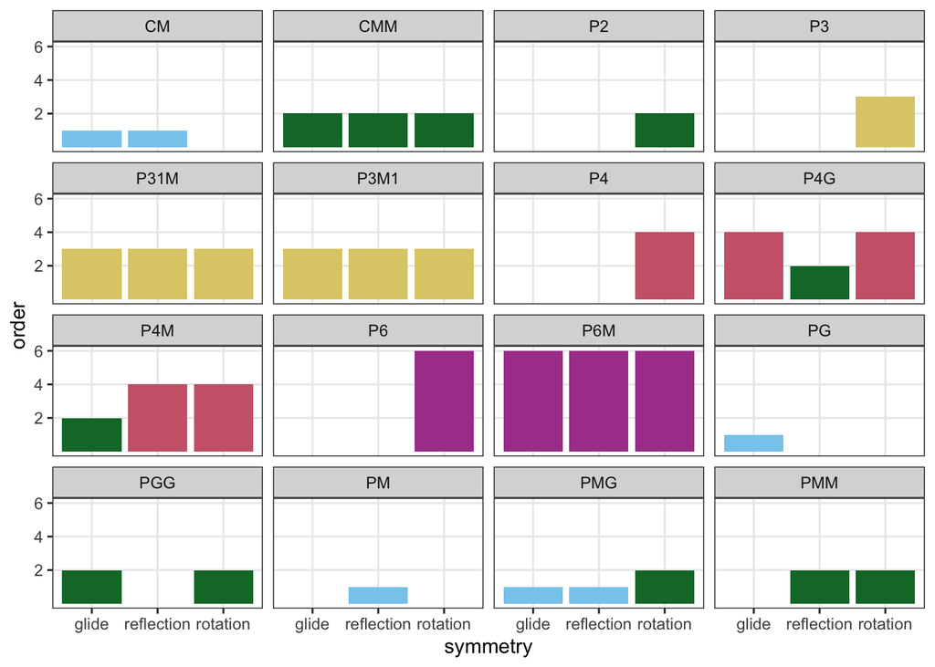

Figure 1.4: Symmetries present in each group.

# 2 Bayesian Analysis

Here are the details of the Bayesian multi-level modelling. Our general approach is:

- Use weakly-informative priors.
- Fit a multi-level model using the lognormal distribution.
- independent variable (wallpaper group) and one dependent variable (rms or threshold).
- maximal random effect structure.
- Check model fit (r̂ statistics and trace plots).
- Extract mcmc samples from the posterior distributions.
- Use these samples to estimate the difference between sub- and super-groups.

## 2.1 Define Priors

In this section we will specify some priors. We then then use a prior-predictive check to assess whether the prior is reasonable or not (i.e., on the same order of magnitude as our measurements).

### 2.1.1 Fixed Effects

Our independent variable is a categorical factor with 16 levels. We will drop the intercept from our model and instead fit a coefficent for each factor level ($y \sim x - 0$). As our dependant variable will be log-transformed, we can use the priors below:

```r
prior <- c(
  set_prior("normal(0,2)", class = "b"),
  set_prior("cauchy(0,2)", class = "sigma"))
```

### 2.1.2 Group-level Effects

We will keep the default weakly informative priors for the group-level (‘random’) effects. From the brms documentation:

> […] restricted to be non-negative and, by default, have a half student-t prior with 3 degrees of freedom and a scale parameter that depends on the standard deviation of the response after applying the link function. Minimally, the scale parameter is 10. This prior is used (a) to be only very weakly informative in order to influence results as few as possible, while (b) providing at least some regularization to considerably improve convergence and sampling efficiency.

### 2.1.3 Prior Predictive Check

Now we can specify our Bayesian multi-level model and priors. Note that as we are using `sample_prior = 'only'`, the model will not learn anything from our data.

```r
m_prior <- brm(data = d_eeg,
  rms ~ wg-1 + (1|subject),
  family = "lognormal",
  prior = prior,
  iter = n_iter ,
  sample_prior = 'only')
```

We can use this model to generate data.

```
## Observations: 320,000
## Variables: 2
## $ key   <chr> "P2", "P2", "P2", "P2", "P2", "P2", "P2", "P2", "P2", "P2"…
## $ value <dbl> 0.31023894, 118.44941441, 2.13786016, 0.10441534, 6.044373…
```

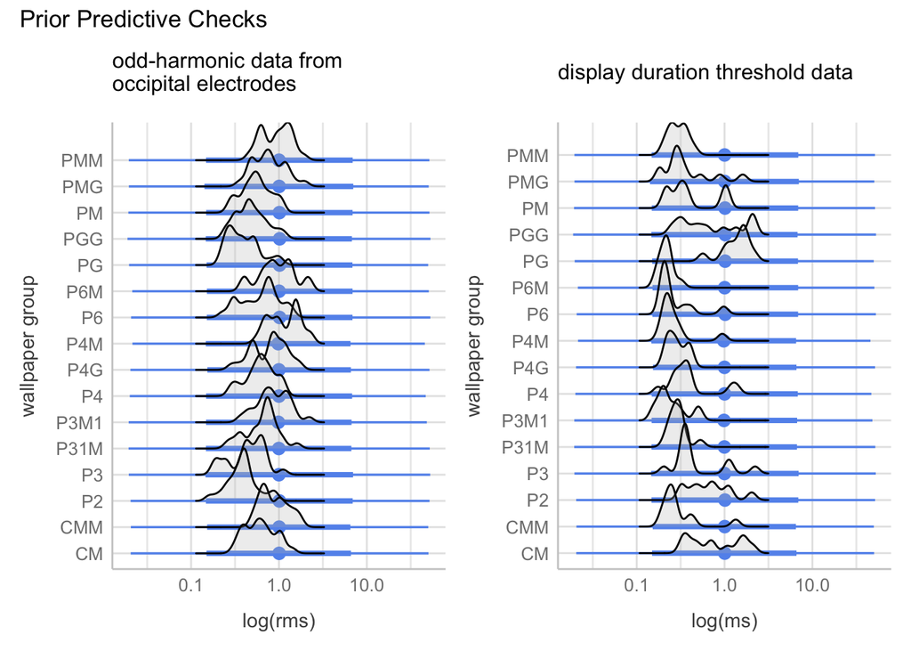

Figure 2.1: The density plot shows the distribution of the empirical data, while the blue line shows the 66% and 95% prediction intervals.

We can see that i) our priors are relatively weak as the predictions span several orders of magnitide, and ii) our empirical data falls within this range.

## 2.2 Compute Posterior

### 2.2.1 Fit Model to EEG Data

We will now fit the model to the data.

```
##  Family: lognormal
##   Links: mu = identity; sigma = identity
## Formula: rms ~ wg - 1 + (1 | subject)
##    Data: d_eeg (Number of observations: 400)
## Samples: 4 chains, each with iter = 10000; warmup = 5000; thin = 1;
##          total post-warmup samples = 20000
##
## Group-Level Effects:
## ~subject (Number of levels: 25)
##               Estimate Est.Error l-95% CI u-95% CI Rhat Bulk_ESS Tail_ESS
## sd(Intercept)     0.38      0.06     0.28     0.52 1.00     1108     2374
##
## Population-Level Effects:
##        Estimate Est.Error l-95% CI u-95% CI Rhat Bulk_ESS Tail_ESS
## wgCM      -0.49      0.09    -0.66    -0.31 1.01      627     1367
## wgCMM     -0.12      0.09    -0.30     0.05 1.01      604     1388
## wgP2      -0.95      0.09    -1.12    -0.77 1.01      630     1338
## wgP3      -0.82      0.09    -0.99    -0.64 1.01      610     1374
## wgP31M    -0.43      0.09    -0.61    -0.26 1.01      619     1301
## wgP3M1    -0.14      0.09    -0.32     0.03 1.01      603     1374
## wgP4      -0.48      0.09    -0.66    -0.31 1.01      622     1280
## wgP4G     -0.25      0.09    -0.43    -0.08 1.01      627     1306
## wgP4M      0.15      0.09    -0.03     0.33 1.01      640     1329
## wgP6      -0.48      0.09    -0.66    -0.30 1.01      614     1299
## wgP6M     -0.04      0.09    -0.22     0.13 1.01      611     1241
## wgPG      -0.93      0.09    -1.11    -0.76 1.01      635     1322
## wgPGG     -0.72      0.09    -0.90    -0.55 1.01      604     1421
## wgPM      -0.59      0.09    -0.77    -0.42 1.01      615     1437
## wgPMG     -0.26      0.09    -0.44    -0.08 1.01      627     1329
## wgPMM     -0.07      0.09    -0.24     0.11 1.01      613     1324
##
## Family Specific Parameters:
##       Estimate Est.Error l-95% CI u-95% CI Rhat Bulk_ESS Tail_ESS
## sigma     0.23      0.01     0.21     0.25 1.00     6723    10176
##
## Samples were drawn using sampling(NUTS). For each parameter, Bulk_ESS
## and Tail_ESS are effective sample size measures, and Rhat is the potential
## scale reduction factor on split chains (at convergence, Rhat = 1).
```

We will now look at the model’s predicts for the average participant (i.e, ignoring the random intercepts).

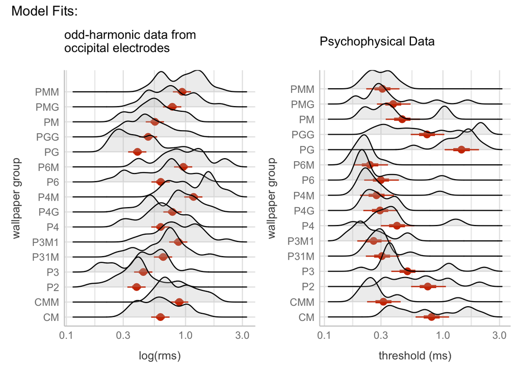

## 2.3 Modelling by symmetry

```
##  Family: lognormal
##   Links: mu = identity; sigma = identity
## Formula: rms ~ rotation + reflection + glide + (1 | subject)
##    Data: dat2 (Number of observations: 400)
## Samples: 4 chains, each with iter = 10000; warmup = 5000; thin = 1;
##          total post-warmup samples = 20000
##
## Group-Level Effects:
## ~subject (Number of levels: 25)
##               Estimate Est.Error l-95% CI u-95% CI Rhat Bulk_ESS Tail_ESS
## sd(Intercept)     0.38      0.06     0.28     0.51 1.00     2197     4800
##
## Population-Level Effects:
##            Estimate Est.Error l-95% CI u-95% CI Rhat Bulk_ESS Tail_ESS
## Intercept     -0.69      0.08    -0.84    -0.53 1.00     1678     3339
## rotation       0.03      0.01     0.01     0.05 1.00    11989    13063
## reflection     0.20      0.01     0.17     0.23 1.00     7648    10997
## glide         -0.08      0.01    -0.11    -0.05 1.00     7598    11496
##
## Family Specific Parameters:
##       Estimate Est.Error l-95% CI u-95% CI Rhat Bulk_ESS Tail_ESS
## sigma     0.29      0.01     0.27     0.32 1.00    11574    12770
##
## Samples were drawn using sampling(NUTS). For each parameter, Bulk_ESS
## and Tail_ESS are effective sample size measures, and Rhat is the potential
## scale reduction factor on split chains (at convergence, Rhat = 1).
```

```
##  Family: lognormal
##   Links: mu = identity; sigma = identity
## Formula: threshold ~ rotation + reflection + glide + (1 | subject)
##    Data: dat3 (Number of observations: 186)
## Samples: 4 chains, each with iter = 10000; warmup = 5000; thin = 1;
##          total post-warmup samples = 20000
##
## Group-Level Effects:
## ~subject (Number of levels: 12)
##               Estimate Est.Error l-95% CI u-95% CI Rhat Bulk_ESS Tail_ESS
## sd(Intercept)     0.36      0.10     0.21     0.61 1.00     4891     8045
##
## Population-Level Effects:
##            Estimate Est.Error l-95% CI u-95% CI Rhat Bulk_ESS Tail_ESS
## Intercept     -0.35      0.13    -0.61    -0.10 1.00     4997     7710
## rotation      -0.15      0.02    -0.19    -0.10 1.00    16129    13626
## reflection    -0.22      0.04    -0.29    -0.15 1.00    11132    13017
## glide          0.12      0.04     0.05     0.19 1.00    10507    12185
##
## Family Specific Parameters:
##       Estimate Est.Error l-95% CI u-95% CI Rhat Bulk_ESS Tail_ESS
## sigma     0.49      0.03     0.44     0.55 1.00    15160    13294
##
## Samples were drawn using sampling(NUTS). For each parameter, Bulk_ESS
## and Tail_ESS are effective sample size measures, and Rhat is the potential
## scale reduction factor on split chains (at convergence, Rhat = 1).
```

## 2.4 Modelling by Subgroup - EEG

```
##  Family: gaussian
##   Links: mu = identity; sigma = identity
## Formula: value ~ d_rot + d_ref + d_gli
##    Data: comp_info (Number of observations: 63)
## Samples: 4 chains, each with iter = 2000; warmup = 1000; thin = 1;
##          total post-warmup samples = 4000
##
## Population-Level Effects:
##           Estimate Est.Error l-95% CI u-95% CI Rhat Bulk_ESS Tail_ESS
## Intercept     0.31      0.05     0.20     0.42 1.00     4763     2935
## d_rot        -0.01      0.02    -0.05     0.03 1.00     4444     3149
## d_ref        -0.13      0.02    -0.17    -0.09 1.00     3458     2932
## d_gli         0.08      0.02     0.05     0.12 1.00     3202     3053
##
## Family Specific Parameters:
##       Estimate Est.Error l-95% CI u-95% CI Rhat Bulk_ESS Tail_ESS
## sigma     0.23      0.02     0.19     0.28 1.00     3837     2854
##
## Samples were drawn using sampling(NUTS). For each parameter, Bulk_ESS
## and Tail_ESS are effective sample size measures, and Rhat is the potential
## scale reduction factor on split chains (at convergence, Rhat = 1).
```

| key | index | d_ref | d_rot | d_gli | value |
| --- | --- | --- | --- | --- | --- |
| CM $\rightarrow$ CMM | 2 | -1 | -2 | -1 | 0.3638848 |
| CM $\rightarrow$ P31M | 3 | -2 | -3 | -2 | 0.0531563 |
| CM $\rightarrow$ P3M1 | 3 | -2 | -3 | -2 | 0.3475369 |
| CM $\rightarrow$ P4G | 4 | -1 | -4 | -3 | 0.2320648 |
| CM $\rightarrow$ P4M | 4 | -3 | -4 | -1 | 0.6392264 |
| CM $\rightarrow$ P6M | 6 | -5 | -6 | -5 | 0.4416409 |
| CM $\rightarrow$ PMG | 4 | 0 | -2 | 0 | 0.2289844 |
| CM $\rightarrow$ PMM | 4 | -1 | -2 | 1 | 0.4181245 |
| CMM $\rightarrow$ P4G | 2 | 0 | -2 | -2 | -0.1318199 |
| CMM $\rightarrow$ P4M | 2 | -2 | -2 | 0 | 0.2753416 |
| CMM $\rightarrow$ P6M | 3 | -4 | -4 | -4 | 0.0777561 |
| P2 $\rightarrow$ CMM | 2 | -2 | 0 | -2 | 0.8244835 |
| P2 $\rightarrow$ P4 | 2 | 0 | -2 | 0 | 0.4645861 |
| P2 $\rightarrow$ P4G | 4 | -2 | -2 | -4 | 0.6926636 |
| P2 $\rightarrow$ P4M | 4 | -4 | -2 | -2 | 1.0998251 |
| P2 $\rightarrow$ P6 | 3 | 0 | -4 | 0 | 0.4658895 |
| P2 $\rightarrow$ P6M | 6 | -6 | -4 | -6 | 0.9022396 |
| P2 $\rightarrow$ PGG | 2 | 0 | 0 | -2 | 0.2224513 |
| P2 $\rightarrow$ PMG | 2 | -1 | 0 | -1 | 0.6895832 |
| P2 $\rightarrow$ PMM | 2 | -2 | 0 | 0 | 0.8787232 |
| P3 $\rightarrow$ P31M | 2 | -3 | 0 | -3 | 0.3841489 |
| P3 $\rightarrow$ P3M1 | 2 | -3 | 0 | -3 | 0.6785295 |
| P3 $\rightarrow$ P6 | 2 | 0 | -3 | 0 | 0.3362833 |
| P3 $\rightarrow$ P6M | 4 | -6 | -3 | -6 | 0.7726335 |
| P31M $\rightarrow$ P6M | 2 | -3 | -3 | -3 | 0.3884846 |
| P3M1 $\rightarrow$ P6M | 2 | -3 | -3 | -3 | 0.0941040 |
| P4 $\rightarrow$ P4G | 2 | -2 | 0 | -4 | 0.2280775 |
| P4 $\rightarrow$ P4M | 2 | -4 | 0 | -2 | 0.6352390 |
| P4G $\rightarrow$ P4M | 2 | -2 | 0 | 2 | 0.4071615 |
| P6 $\rightarrow$ P6M | 2 | -6 | 0 | -6 | 0.4363502 |
| PG $\rightarrow$ CM | 2 | -1 | 0 | 0 | 0.4442469 |
| PG $\rightarrow$ CMM | 4 | -2 | -2 | -1 | 0.8081316 |
| PG $\rightarrow$ P31M | 6 | -3 | -3 | -2 | 0.4974032 |
| PG $\rightarrow$ P3M1 | 6 | -3 | -3 | -2 | 0.7917838 |
| PG $\rightarrow$ P4G | 4 | -2 | -4 | -3 | 0.6763117 |
| PG $\rightarrow$ P4M | 8 | -4 | -4 | -1 | 1.0834732 |
| PG $\rightarrow$ P6M | 12 | -6 | -6 | -5 | 0.8858877 |
| PG $\rightarrow$ PGG | 2 | 0 | -2 | -1 | 0.2060994 |
| PG $\rightarrow$ PM | 2 | -1 | 0 | 1 | 0.3387859 |
| PG $\rightarrow$ PMG | 2 | -1 | -2 | 0 | 0.6732313 |
| PG $\rightarrow$ PMM | 4 | -2 | -2 | 1 | 0.8623713 |
| PGG $\rightarrow$ CMM | 2 | -2 | 0 | 0 | 0.6020322 |
| PGG $\rightarrow$ P4G | 2 | -2 | -2 | -2 | 0.4702123 |
| PGG $\rightarrow$ P4M | 4 | -4 | -2 | 0 | 0.8773738 |
| PGG $\rightarrow$ P6M | 6 | -6 | -4 | -4 | 0.6797883 |
| PGG $\rightarrow$ PMG | 2 | -1 | 0 | 1 | 0.4671319 |
| PGG $\rightarrow$ PMM | 4 | -2 | 0 | 2 | 0.6562719 |
| PM $\rightarrow$ CMM | 4 | -1 | -2 | -2 | 0.4693457 |
| PM $\rightarrow$ P31M | 6 | -2 | -3 | -3 | 0.1586172 |
| PM $\rightarrow$ P3M1 | 6 | -2 | -3 | -3 | 0.4529978 |
| PM $\rightarrow$ P4G | 8 | -1 | -4 | -4 | 0.3375258 |
| PM $\rightarrow$ P4M | 4 | -3 | -4 | -2 | 0.7446873 |
| PM $\rightarrow$ P6M | 12 | -5 | -6 | -6 | 0.5471018 |
| PM $\rightarrow$ PMG | 2 | 0 | -2 | -1 | 0.3344454 |
| PM $\rightarrow$ PMM | 2 | -1 | -2 | 0 | 0.5235854 |
| PMG $\rightarrow$ CMM | 2 | -1 | 0 | -1 | 0.1349003 |
| PMG $\rightarrow$ P4G | 4 | -1 | -2 | -3 | 0.0030804 |
| PMG $\rightarrow$ P4M | 4 | -3 | -2 | -1 | 0.4102419 |
| PMG $\rightarrow$ P6M | 6 | -5 | -4 | -5 | 0.2126564 |
| PMG $\rightarrow$ PMM | 2 | -1 | 0 | 1 | 0.1891400 |
| PMM $\rightarrow$ P4G | 4 | 0 | -2 | -4 | -0.1860596 |
| PMM $\rightarrow$ P4M | 2 | -2 | -2 | -2 | 0.2211019 |
| PMM $\rightarrow$ P6M | 6 | -4 | -4 | -6 | 0.0235164 |

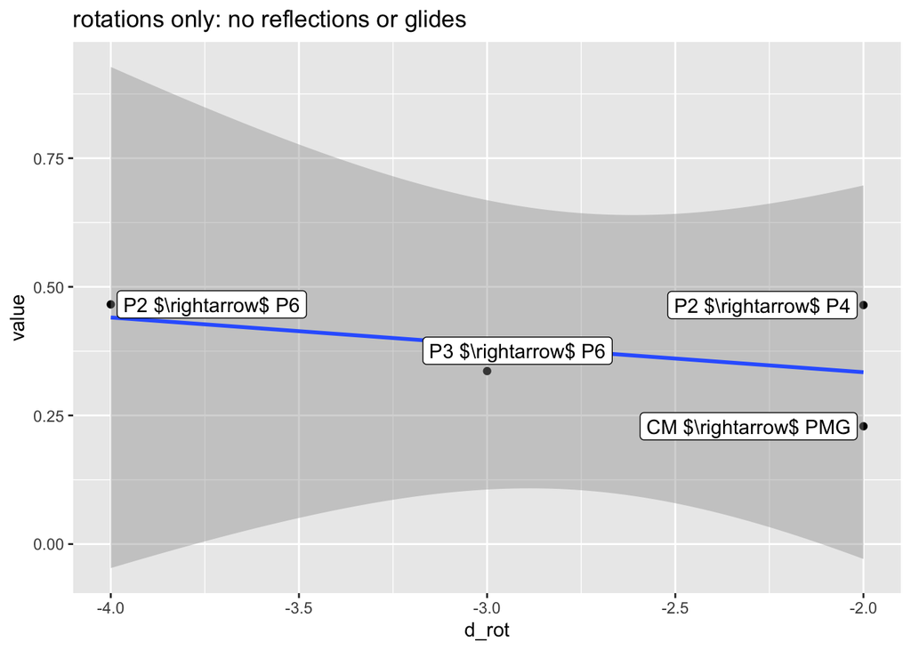

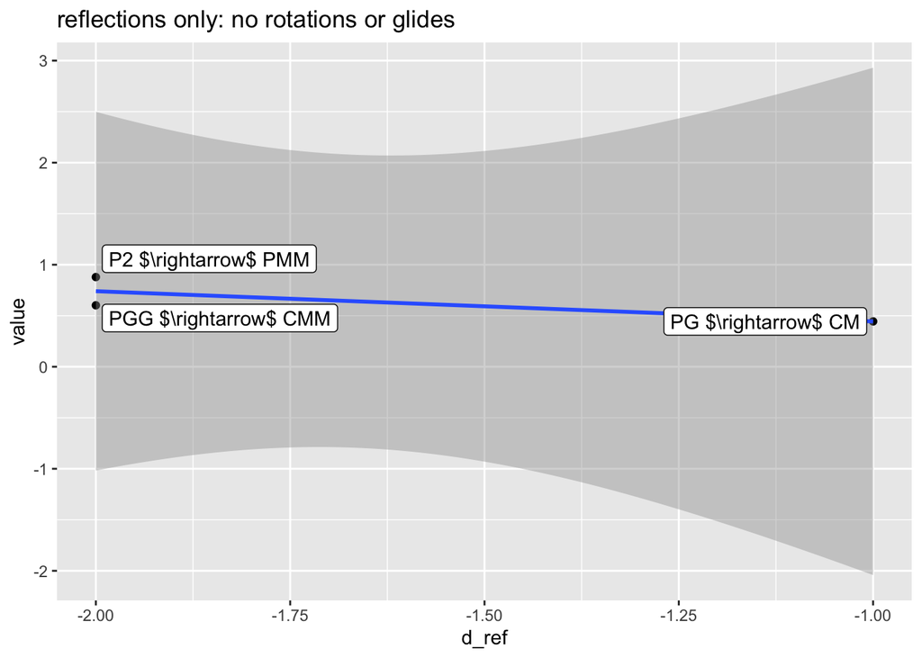

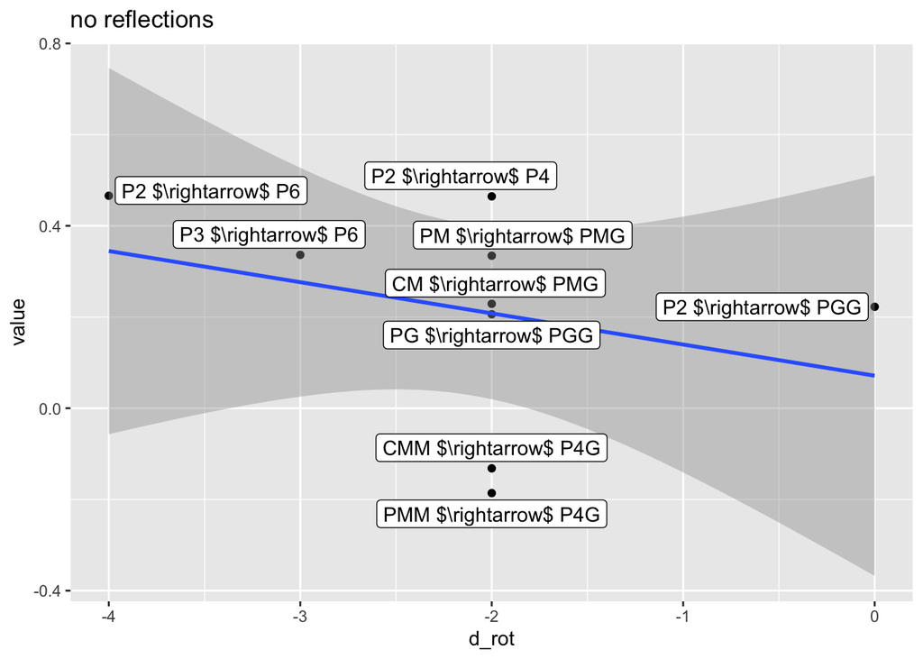

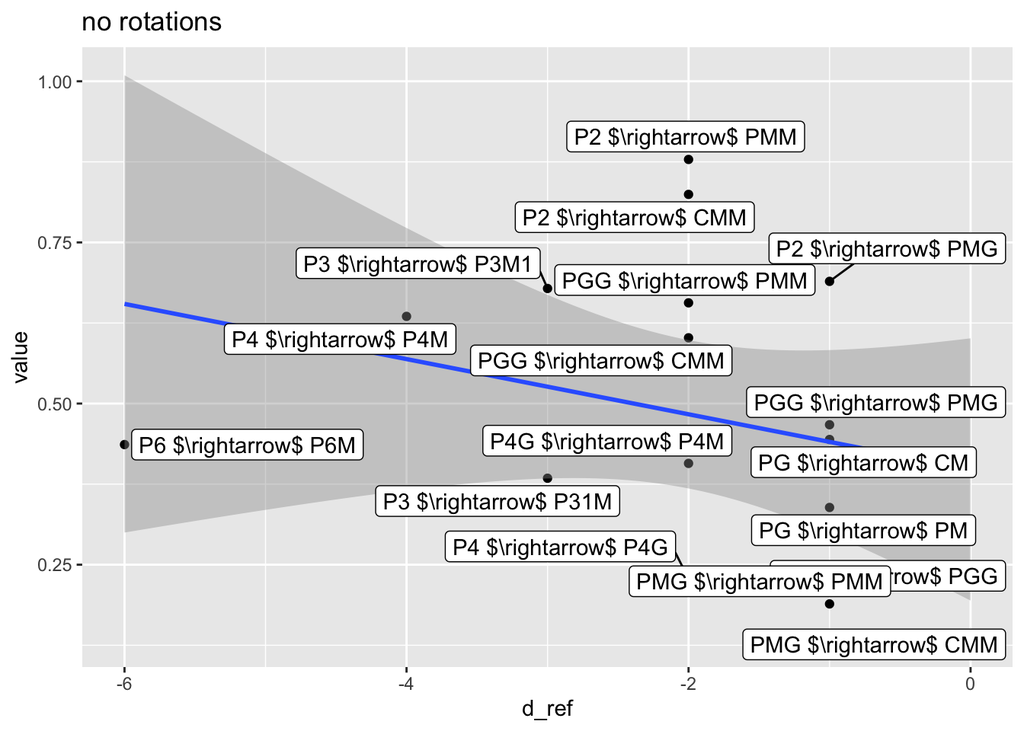

## 2.5 Modelling by Subgroup - Beh

```
##  Family: gaussian
##   Links: mu = identity; sigma = identity
## Formula: value ~ d_rot + d_ref + d_gli
##    Data: comp_info (Number of observations: 63)
## Samples: 4 chains, each with iter = 2000; warmup = 1000; thin = 1;
##          total post-warmup samples = 4000
##
## Population-Level Effects:
##           Estimate Est.Error l-95% CI u-95% CI Rhat Bulk_ESS Tail_ESS
## Intercept    -0.41      0.10    -0.60    -0.22 1.00     4773     3106
## d_rot         0.13      0.04     0.06     0.20 1.00     3949     2855
## d_ref         0.12      0.04     0.04     0.19 1.00     3641     2982
## d_gli        -0.13      0.04    -0.20    -0.06 1.00     3030     2793
##
## Family Specific Parameters:
##       Estimate Est.Error l-95% CI u-95% CI Rhat Bulk_ESS Tail_ESS
## sigma     0.41      0.04     0.34     0.50 1.00     4049     2661
##
## Samples were drawn using sampling(NUTS). For each parameter, Bulk_ESS
## and Tail_ESS are effective sample size measures, and Rhat is the potential
## scale reduction factor on split chains (at convergence, Rhat = 1).
```

| key | index | d_ref | d_rot | d_gli | value |
| --- | --- | --- | --- | --- | --- |
| CM $\rightarrow$ CMM | 2 | -1 | -2 | -1 | -0.9360801 |
| CM $\rightarrow$ P31M | 3 | -2 | -3 | -2 | -0.9637817 |
| CM $\rightarrow$ P3M1 | 3 | -2 | -3 | -2 | -1.1275289 |
| CM $\rightarrow$ P4G | 4 | -1 | -4 | -3 | -1.0029863 |
| CM $\rightarrow$ P4M | 4 | -3 | -4 | -1 | -1.0711080 |
| CM $\rightarrow$ P6M | 6 | -5 | -6 | -5 | -1.1967063 |
| CM $\rightarrow$ PMG | 4 | 0 | -2 | 0 | -0.7460574 |
| CM $\rightarrow$ PMM | 4 | -1 | -2 | 1 | -0.9555963 |
| CMM $\rightarrow$ P4G | 2 | 0 | -2 | -2 | -0.0669062 |
| CMM $\rightarrow$ P4M | 2 | -2 | -2 | 0 | -0.1350279 |
| CMM $\rightarrow$ P6M | 3 | -4 | -4 | -4 | -0.2606262 |
| P2 $\rightarrow$ CMM | 2 | -2 | 0 | -2 | -0.8622939 |
| P2 $\rightarrow$ P4 | 2 | 0 | -2 | 0 | -0.5986595 |
| P2 $\rightarrow$ P4G | 4 | -2 | -2 | -4 | -0.9292001 |
| P2 $\rightarrow$ P4M | 4 | -4 | -2 | -2 | -0.9973219 |
| P2 $\rightarrow$ P6 | 3 | 0 | -4 | 0 | -0.9115502 |
| P2 $\rightarrow$ P6M | 6 | -6 | -4 | -6 | -1.1229202 |
| P2 $\rightarrow$ PGG | 2 | 0 | 0 | -2 | -0.0155207 |
| P2 $\rightarrow$ PMG | 2 | -1 | 0 | -1 | -0.6722713 |
| P2 $\rightarrow$ PMM | 2 | -2 | 0 | 0 | -0.8818102 |
| P3 $\rightarrow$ P31M | 2 | -3 | 0 | -3 | -0.4944855 |
| P3 $\rightarrow$ P3M1 | 2 | -3 | 0 | -3 | -0.6582326 |
| P3 $\rightarrow$ P6 | 2 | 0 | -3 | 0 | -0.5160400 |
| P3 $\rightarrow$ P6M | 4 | -6 | -3 | -6 | -0.7274100 |
| P31M $\rightarrow$ P6M | 2 | -3 | -3 | -3 | -0.2329246 |
| P3M1 $\rightarrow$ P6M | 2 | -3 | -3 | -3 | -0.0691774 |
| P4 $\rightarrow$ P4G | 2 | -2 | 0 | -4 | -0.3305407 |
| P4 $\rightarrow$ P4M | 2 | -4 | 0 | -2 | -0.3986624 |
| P4G $\rightarrow$ P4M | 2 | -2 | 0 | 2 | -0.0681217 |
| P6 $\rightarrow$ P6M | 2 | -6 | 0 | -6 | -0.2113700 |
| PG $\rightarrow$ CM | 2 | -1 | 0 | 0 | -0.5803318 |
| PG $\rightarrow$ CMM | 4 | -2 | -2 | -1 | -1.5164119 |
| PG $\rightarrow$ P31M | 6 | -3 | -3 | -2 | -1.5441136 |
| PG $\rightarrow$ P3M1 | 6 | -3 | -3 | -2 | -1.7078607 |
| PG $\rightarrow$ P4G | 4 | -2 | -4 | -3 | -1.5833181 |
| PG $\rightarrow$ P4M | 8 | -4 | -4 | -1 | -1.6514398 |
| PG $\rightarrow$ P6M | 12 | -6 | -6 | -5 | -1.7770381 |
| PG $\rightarrow$ PGG | 2 | 0 | -2 | -1 | -0.6696387 |
| PG $\rightarrow$ PM | 2 | -1 | 0 | 1 | -1.1509669 |
| PG $\rightarrow$ PMG | 2 | -1 | -2 | 0 | -1.3263893 |
| PG $\rightarrow$ PMM | 4 | -2 | -2 | 1 | -1.5359281 |
| PGG $\rightarrow$ CMM | 2 | -2 | 0 | 0 | -0.8467732 |
| PGG $\rightarrow$ P4G | 2 | -2 | -2 | -2 | -0.9136794 |
| PGG $\rightarrow$ P4M | 4 | -4 | -2 | 0 | -0.9818012 |
| PGG $\rightarrow$ P6M | 6 | -6 | -4 | -4 | -1.1073995 |
| PGG $\rightarrow$ PMG | 2 | -1 | 0 | 1 | -0.6567506 |
| PGG $\rightarrow$ PMM | 4 | -2 | 0 | 2 | -0.8662894 |
| PM $\rightarrow$ CMM | 4 | -1 | -2 | -2 | -0.3654451 |
| PM $\rightarrow$ P31M | 6 | -2 | -3 | -3 | -0.3931467 |
| PM $\rightarrow$ P3M1 | 6 | -2 | -3 | -3 | -0.5568939 |
| PM $\rightarrow$ P4G | 8 | -1 | -4 | -4 | -0.4323513 |
| PM $\rightarrow$ P4M | 4 | -3 | -4 | -2 | -0.5004730 |
| PM $\rightarrow$ P6M | 12 | -5 | -6 | -6 | -0.6260713 |
| PM $\rightarrow$ PMG | 2 | 0 | -2 | -1 | -0.1754224 |
| PM $\rightarrow$ PMM | 2 | -1 | -2 | 0 | -0.3849613 |
| PMG $\rightarrow$ CMM | 2 | -1 | 0 | -1 | -0.1900227 |
| PMG $\rightarrow$ P4G | 4 | -1 | -2 | -3 | -0.2569289 |
| PMG $\rightarrow$ P4M | 4 | -3 | -2 | -1 | -0.3250506 |
| PMG $\rightarrow$ P6M | 6 | -5 | -4 | -5 | -0.4506489 |
| PMG $\rightarrow$ PMM | 2 | -1 | 0 | 1 | -0.2095389 |
| PMM $\rightarrow$ P4G | 4 | 0 | -2 | -4 | -0.0473900 |
| PMM $\rightarrow$ P4M | 2 | -2 | -2 | -2 | -0.1155117 |
| PMM $\rightarrow$ P6M | 6 | -4 | -4 | -6 | -0.2411100 |

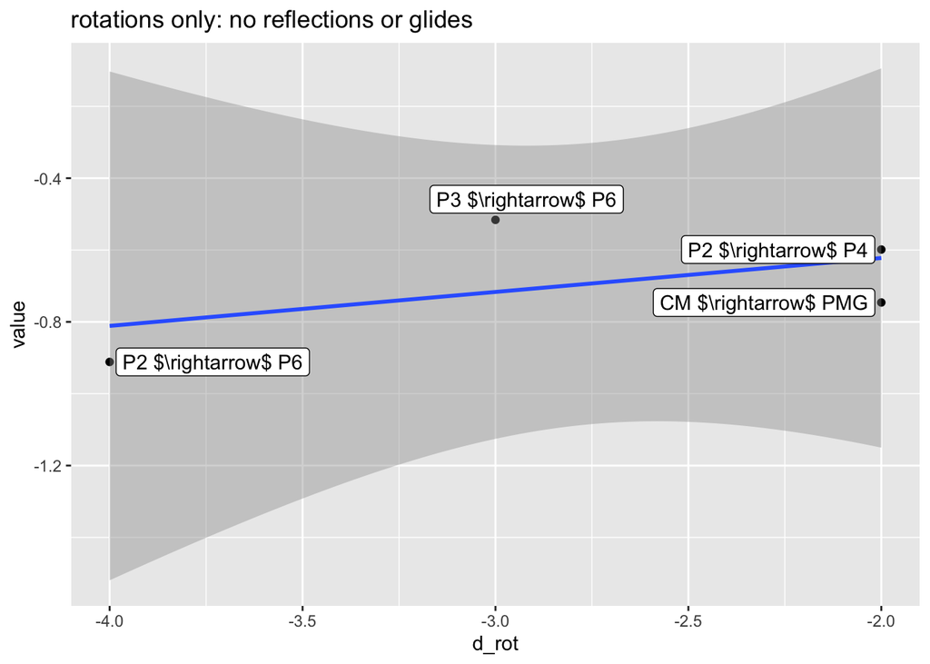

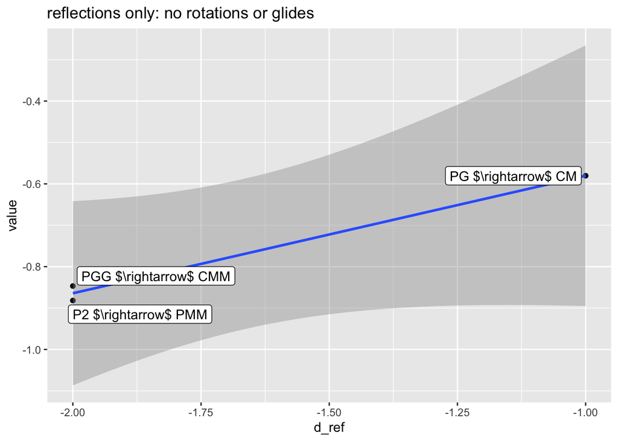

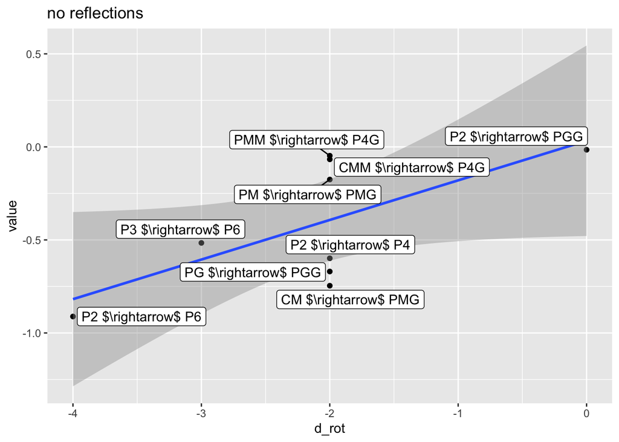

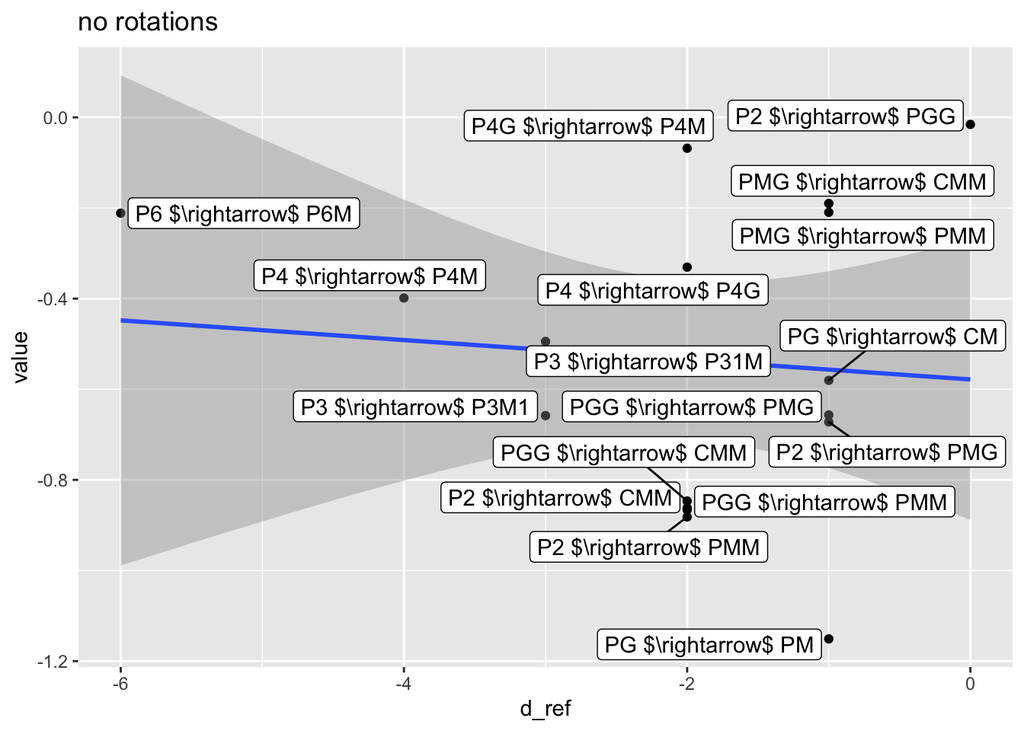